## Manuscript feedback

FCL annotated draft  
Revision folder · 10 November 2026

Project 2 · CTJ manuscript · Feedback register

# Comments, with their context

Every highlighted comment and strikeout from the reviewed manuscript, connected to its marked passage, PDF page and paper section. Use the IDs when sharing additional notes or deciding how to revise the CTJ paper and Chapter 3.

**60** annotations**58** written comments**2** strikeouts**5** pages with feedback

**Version matters.** Quotations and marked passages come from the annotated PDF, not the current source files. Pages refer to the nine-page reading preview; PDF and printed page numbers agree. No annotations were found on pages 6–9.

**FCL-050 is partly addressed.** Andrew confirmed that the three-decimal reporting rule was introduced after this draft was sent for feedback. Its separate question about the pooled result and Table 2 is still open.

**No revision decisions are implied.** Comments are preserved verbatim, including arrow responses already in the current PDF. Chapter destinations are provisional. The manuscript and thesis chapter have not been edited.

60 annotations

Open annotated PDFDownload extracted data

No annotations match these filters.

## PDF page 1 15 annotations

FCL-001PDF p. 1HighlightOpen

### Introduction / No subsection

#### Marked text

> ,5–8

#### Surrounding text / location

Design-stage methods include covariate-constrained randomization, randomized saturation and independent-set or spatial cluster designs,⁵–⁸ which serve different objectives.

#### Annotation contents · flin33

> Put citation to the end of the sentence?

**View marked passage in the original PDF**

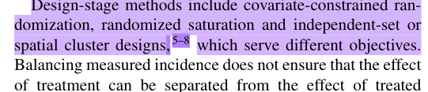

Text selected by annotation coordinates; line-wrap hyphens and mathematical glyph order may reflect PDF extraction. The image below preserves the marked original.

**Chapter 3 follow-up and related comments**

**Provisional chapter destination:** Introduction

Provisional topic mapping, not a verified line-level match or an approved revision.

**Related comments:** FCL-009

Your notes / intended response

FCL-002PDF p. 1HighlightOpen

### Introduction / No subsection

#### Marked text

> its

#### Surrounding text / location

In a strict checkerboard with edge neighbors, for example, a cluster’s exposure to treated neighbors is fully determined by its own treatment.

#### Annotation contents · flin33

> who is "its"?

**View marked passage in the original PDF**

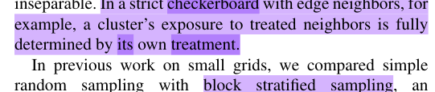

Text selected by annotation coordinates; line-wrap hyphens and mathematical glyph order may reflect PDF extraction. The image below preserves the marked original.

**Chapter 3 follow-up and related comments**

**Provisional chapter destination:** Introduction

Provisional topic mapping, not a verified line-level match or an approved revision.

**Related comments:** FCL-003 · FCL-004 · FCL-010

Your notes / intended response

FCL-003PDF p. 1HighlightOpen

### Introduction / No subsection

#### Marked text

> checkerboard

#### Surrounding text / location

In a strict checkerboard with edge neighbors, for example, a cluster’s exposure to treated neighbors is fully determined by its own treatment.

#### Annotation contents · flin33

> use "checkerboard design"?

**View marked passage in the original PDF**

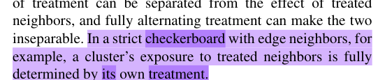

Text selected by annotation coordinates; line-wrap hyphens and mathematical glyph order may reflect PDF extraction. The image below preserves the marked original.

**Chapter 3 follow-up and related comments**

**Provisional chapter destination:** Introduction

Provisional topic mapping, not a verified line-level match or an approved revision.

**Related comments:** FCL-002 · FCL-004 · FCL-010

Your notes / intended response

FCL-004PDF p. 1HighlightOpen

### Introduction / No subsection

#### Marked text

> treatment.

#### Surrounding text / location

In a strict checkerboard with edge neighbors, for example, a cluster’s exposure to treated neighbors is fully determined by its own treatment.

#### Annotation contents · flin33

> Do you want to cite the first paper here?

**View marked passage in the original PDF**

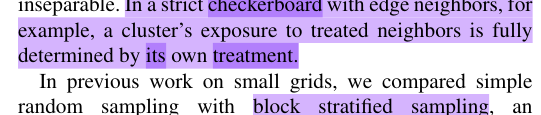

Text selected by annotation coordinates; line-wrap hyphens and mathematical glyph order may reflect PDF extraction. The image below preserves the marked original.

**Chapter 3 follow-up and related comments**

**Provisional chapter destination:** Introduction

Provisional topic mapping, not a verified line-level match or an approved revision.

**Related comments:** FCL-002 · FCL-003 · FCL-010

Your notes / intended response

FCL-005PDF p. 1HighlightOpen

### Introduction / No subsection

#### Marked text

> That work weighed average estimation accuracy against the risk of a poor

#### Surrounding text / location

That work weighed average estimation accuracy against the risk of a poor realized allocation.

#### Annotation contents · flin33

> What does this sentence mean?

**View marked passage in the original PDF**

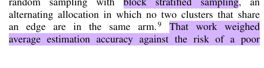

The highlight ends at “poor” on page 1. The context sentence continues “realized allocation” at the top of the right column.

**Chapter 3 follow-up and related comments**

**Provisional chapter destination:** Introduction

Provisional topic mapping, not a verified line-level match or an approved revision.

**Related comments:** FCL-006 · FCL-007 · FCL-011

Your notes / intended response

FCL-006PDF p. 1HighlightOpen

### Introduction / No subsection

#### Marked text

> The comparison includes simple random sampling (SRS), meaning complete randomization of a fixed number of clusters, and the alternating allocation, here called Checkerboard.

#### Surrounding text / location

The comparison includes simple random sampling (SRS), meaning complete randomization of a fixed number of clusters, and the alternating allocation, here called Checkerboard.

#### Annotation contents · flin33

> Consider deleting this sentence and revise the first sentence of the paragraph to cover SRS and checkerboard.

**View marked passage in the original PDF**

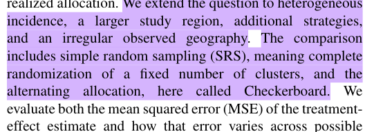

Text selected by annotation coordinates; line-wrap hyphens and mathematical glyph order may reflect PDF extraction. The image below preserves the marked original.

**Chapter 3 follow-up and related comments**

**Provisional chapter destination:** Introduction

Provisional topic mapping, not a verified line-level match or an approved revision.

**Related comments:** FCL-005 · FCL-007 · FCL-011

Your notes / intended response

FCL-007PDF p. 1HighlightOpen

### Introduction / No subsection

#### Marked text

> We extend the question to heterogeneous incidence, a larger study region, additional strategies, and an irregular observed geography

#### Surrounding text / location

We extend the question to heterogeneous incidence, a larger study region, additional strategies, and an irregular observed geography

#### Annotation contents · flin33

> This sentence is more like the last sentence of the paragraph.

**View marked passage in the original PDF**

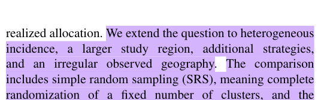

Text selected by annotation coordinates; line-wrap hyphens and mathematical glyph order may reflect PDF extraction. The image below preserves the marked original.

**Chapter 3 follow-up and related comments**

**Provisional chapter destination:** Introduction

Provisional topic mapping, not a verified line-level match or an approved revision.

**Related comments:** FCL-005 · FCL-006 · FCL-011

Your notes / intended response

FCL-008PDF p. 1HighlightOpen

### Introduction / No subsection

#### Marked text

> Two allocations with the same number of treated clusters can then provide very different information about the treatment effect.

#### Surrounding text / location

Two allocations with the same number of treated clusters can then provide very different information about the treatment effect.

#### Annotation contents · flin33

> Cite some paper.

**View marked passage in the original PDF**

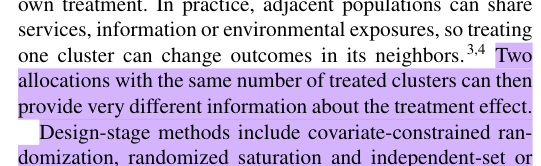

Text selected by annotation coordinates; line-wrap hyphens and mathematical glyph order may reflect PDF extraction. The image below preserves the marked original.

**Chapter 3 follow-up and related comments**

**Provisional chapter destination:** Introduction

Provisional topic mapping, not a verified line-level match or an approved revision.

**Related comments:** None assigned

Your notes / intended response

FCL-009PDF p. 1HighlightOpen

### Introduction / No subsection

#### Marked text

> Design-stage methods include covariate-constrained ran- domization, randomized saturation and independent-set or spatial cluster designs,5–8 which serve different objectives.

#### Surrounding text / location

Design-stage methods include covariate-constrained ran- domization, randomized saturation and independent-set or spatial cluster designs,5–8 which serve different objectives.

#### Annotation contents · flin33

> How about this? "Design-stage methods, including covariate-constrained randomization, randomized saturation and independent-set, and spatial cluster designs,5–8 serve different objectives."

**View marked passage in the original PDF**

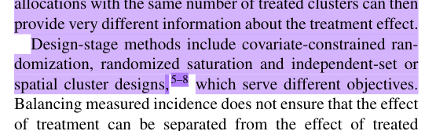

Text selected by annotation coordinates; line-wrap hyphens and mathematical glyph order may reflect PDF extraction. The image below preserves the marked original.

**Chapter 3 follow-up and related comments**

**Provisional chapter destination:** Introduction

Provisional topic mapping, not a verified line-level match or an approved revision.

**Related comments:** FCL-001

Your notes / intended response

FCL-010PDF p. 1HighlightOpen

### Introduction / No subsection

#### Marked text

> In a strict checkerboard with edge neighbors, for example, a cluster’s exposure to treated neighbors is fully determined by its own treatment.

#### Surrounding text / location

In a strict checkerboard with edge neighbors, for example, a cluster’s exposure to treated neighbors is fully determined by its own treatment.

#### Annotation contents · flin33

> Not sure I understand this sentence

**View marked passage in the original PDF**

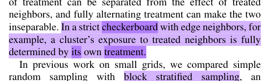

Text selected by annotation coordinates; line-wrap hyphens and mathematical glyph order may reflect PDF extraction. The image below preserves the marked original.

**Chapter 3 follow-up and related comments**

**Provisional chapter destination:** Introduction

Provisional topic mapping, not a verified line-level match or an approved revision.

**Related comments:** FCL-002 · FCL-003 · FCL-004

Your notes / intended response

FCL-011PDF p. 1HighlightOpen

### Introduction / No subsection

#### Marked text

> block stratified sampling

#### Surrounding text / location

In previous work on small grids, we compared simple random sampling with block stratified sampling, an alternating allocation in which no two clusters that share an edge are in the same arm.

#### Annotation contents · flin33

> Is this checkerboard design?

**View marked passage in the original PDF**

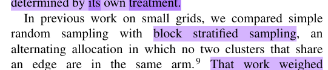

Text selected by annotation coordinates; line-wrap hyphens and mathematical glyph order may reflect PDF extraction. The image below preserves the marked original.

**Chapter 3 follow-up and related comments**

**Provisional chapter destination:** Introduction

Provisional topic mapping, not a verified line-level match or an approved revision.

**Related comments:** FCL-005 · FCL-006 · FCL-007

Your notes / intended response

FCL-012PDF p. 1HighlightOpen

### Introduction / No subsection

#### Marked text

> Our application supports planning

#### Surrounding text / location

Our application supports planning an education intervention for healthcare professionals involved in sudden unexpected death (SUD) prevention.

#### Annotation contents · flin33

> Suggestion: "In this article, we aim to plan"

**View marked passage in the original PDF**

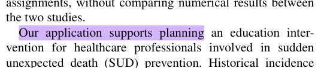

Text selected by annotation coordinates; line-wrap hyphens and mathematical glyph order may reflect PDF extraction. The image below preserves the marked original.

**Chapter 3 follow-up and related comments**

**Provisional chapter destination:** Introduction

Provisional topic mapping, not a verified line-level match or an approved revision.

**Related comments:** None assigned

Your notes / intended response

FCL-013PDF p. 1HighlightOpen

### Introduction / No subsection

#### Marked text

> challenges

#### Surrounding text / location

Spatial interference challenges the assumption that a cluster’s outcome depends only on its own treatment.

#### Annotation contents · flin33

> use "further challenges"?

**View marked passage in the original PDF**

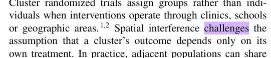

Text selected by annotation coordinates; line-wrap hyphens and mathematical glyph order may reflect PDF extraction. The image below preserves the marked original.

**Chapter 3 follow-up and related comments**

**Provisional chapter destination:** Introduction

Provisional topic mapping, not a verified line-level match or an approved revision.

**Related comments:** None assigned

Your notes / intended response

FCL-014PDF p. 1HighlightOpen

### Abstract / Background/Aims

#### Marked text

> the error under an unfavorable realized assignment (allocation risk)

#### Surrounding text / location

We compared six treatment assignment designs and simple random sampling (SRS) on two criteria, the average estimation error and the error under an unfavorable realized assignment (allocation risk).

#### Annotation contents · flin33

> Need to understand this

**View marked passage in the original PDF**

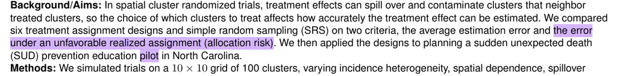

Text selected by annotation coordinates; line-wrap hyphens and mathematical glyph order may reflect PDF extraction. The image below preserves the marked original.

**Chapter 3 follow-up and related comments**

**Provisional chapter destination:** Abstract

Provisional topic mapping, not a verified line-level match or an approved revision.

**Related comments:** FCL-029 · FCL-043

Your notes / intended response

FCL-015PDF p. 1HighlightOpen

### Abstract / Background/Aims

#### Marked text

> pilot

#### Surrounding text / location

We then applied the designs to planning a sudden unexpected death (SUD) prevention education pilot in North Carolina.

#### Annotation contents · flin33

> use "pilot trial"?

**View marked passage in the original PDF**

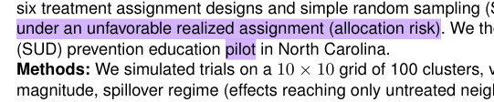

Text selected by annotation coordinates; line-wrap hyphens and mathematical glyph order may reflect PDF extraction. The image below preserves the marked original.

**Chapter 3 follow-up and related comments**

**Provisional chapter destination:** Abstract

Provisional topic mapping, not a verified line-level match or an approved revision.

**Related comments:** None assigned

Your notes / intended response

## PDF page 2 20 annotations

FCL-016PDF p. 2HighlightOpen

### Methods / Outcome model, estimation and allocation risk

#### Marked text

> ϵ ∼ N(0,I),

#### Surrounding text / location

Equation (1): Y = (I − ρW)⁻¹[τZ + S(Z) + βX + ε], ε ∼ N(0, I).

#### Annotation contents · flin33

> Suggest moving it to the sentence. Make a one-line formula, if possible.

**View marked passage in the original PDF**

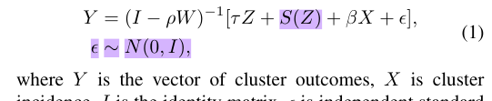

Text selected by annotation coordinates; line-wrap hyphens and mathematical glyph order may reflect PDF extraction. The image below preserves the marked original.

**Chapter 3 follow-up and related comments**

**Provisional chapter destination:** Methods → Spatial Structure, Outcome Model and Estimand; Estimation and Performance Criteria

Provisional topic mapping, not a verified line-level match or an approved revision.

**Related comments:** FCL-030

Your notes / intended response

FCL-017PDF p. 2HighlightOpen

### Methods / Outcome model, estimation and allocation risk

#### Marked text

> Queen contiguity was used for the primary analysis and rook contiguity for a sensitivity analysis

#### Surrounding text / location

Queen contiguity was used for the primary analysis and rook contiguity for a sensitivity analysis

#### Annotation contents · flin33

> This sentence came from nowhere.

**View marked passage in the original PDF**

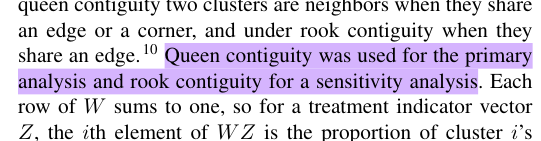

Text selected by annotation coordinates; line-wrap hyphens and mathematical glyph order may reflect PDF extraction. The image below preserves the marked original.

**Chapter 3 follow-up and related comments**

**Provisional chapter destination:** Methods → Spatial Structure, Outcome Model and Estimand; Estimation and Performance Criteria

Provisional topic mapping, not a verified line-level match or an approved revision.

**Related comments:** None assigned

Your notes / intended response

FCL-018PDF p. 2HighlightOpen

### Methods / Outcome model, estimation and allocation risk

#### Marked text

> noise

#### Surrounding text / location

ε is independent standard normal noise (so τ is in units of its standard deviation) and ρ is the spatial dependence of the outcomes.

#### Annotation contents · flin33

> noise; \tau is in units...

**View marked passage in the original PDF**

**Chapter 3 follow-up and related comments**

**Provisional chapter destination:** Methods → Spatial Structure, Outcome Model and Estimand; Estimation and Performance Criteria

Provisional topic mapping, not a verified line-level match or an approved revision.

**Related comments:** FCL-019 · FCL-020

Your notes / intended response

FCL-019PDF p. 2StrikeOutOpen

### Methods / Outcome model, estimation and allocation risk

#### Marked text

> (so

#### Surrounding text / location

ε is independent standard normal noise (so τ is in units of its standard deviation) and ρ is the spatial dependence of the outcomes.

#### Annotation contents · flin33

> *No written comment; strikeout annotation.*

**View marked passage in the original PDF**

Strikeout only. The PDF contains no written comment for this mark; the marked text is the feedback.

**Chapter 3 follow-up and related comments**

**Provisional chapter destination:** Methods → Spatial Structure, Outcome Model and Estimand; Estimation and Performance Criteria

Provisional topic mapping, not a verified line-level match or an approved revision.

**Related comments:** FCL-018 · FCL-020

Your notes / intended response

FCL-020PDF p. 2HighlightOpen

### Methods / Outcome model, estimation and allocation risk

#### Marked text

> deviation)

#### Surrounding text / location

ε is independent standard normal noise (so τ is in units of its standard deviation) and ρ is the spatial dependence of the outcomes.

#### Annotation contents · flin33

> deviation,

**View marked passage in the original PDF**

**Chapter 3 follow-up and related comments**

**Provisional chapter destination:** Methods → Spatial Structure, Outcome Model and Estimand; Estimation and Performance Criteria

Provisional topic mapping, not a verified line-level match or an approved revision.

**Related comments:** FCL-018 · FCL-019

Your notes / intended response

FCL-021PDF p. 2HighlightOpen

### Methods / Outcome model, estimation and allocation risk

#### Marked text

> The coefficient β sets how strongly incidence shifts the baseline outcome.

#### Surrounding text / location

The coefficient β sets how strongly incidence shifts the baseline outcome.

#### Annotation contents · flin33

> Using "baseline outcome" may be confusing to statistical readers.

**View marked passage in the original PDF**

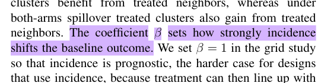

Text selected by annotation coordinates; line-wrap hyphens and mathematical glyph order may reflect PDF extraction. The image below preserves the marked original.

**Chapter 3 follow-up and related comments**

**Provisional chapter destination:** Methods → Spatial Structure, Outcome Model and Estimand; Estimation and Performance Criteria

Provisional topic mapping, not a verified line-level match or an approved revision.

**Related comments:** FCL-022 · FCL-047 · FCL-053

Your notes / intended response

FCL-022PDF p. 2HighlightOpen

### Methods / Outcome model, estimation and allocation risk

#### Marked text

> Investigators can choose β to suit their own outcome.

#### Surrounding text / location

Investigators can choose β to suit their own outcome.

#### Annotation contents · flin33

> "choose", but "not estimated"?

**View marked passage in the original PDF**

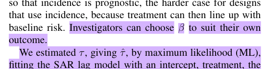

Text selected by annotation coordinates; line-wrap hyphens and mathematical glyph order may reflect PDF extraction. The image below preserves the marked original.

**Chapter 3 follow-up and related comments**

**Provisional chapter destination:** Methods → Spatial Structure, Outcome Model and Estimand; Estimation and Performance Criteria

Provisional topic mapping, not a verified line-level match or an approved revision.

**Related comments:** FCL-021 · FCL-047 · FCL-053

Your notes / intended response

FCL-023PDF p. 2HighlightOpen

### Methods / Outcome model, estimation and allocation risk

#### Marked text

> We estimated τ, giving τˆ, by maximum likelihood (ML), fitting the SAR lag model with an intercept, treatment, the true regime-specific spillover covariate and, in the grid study, incidence.

#### Surrounding text / location

We estimated τ, giving τˆ, by maximum likelihood (ML), fitting the SAR lag model with an intercept, treatment, the true regime-specific spillover covariate and, in the grid study, incidence.

#### Annotation contents · flin33

> This sentence is too much broken.

**View marked passage in the original PDF**

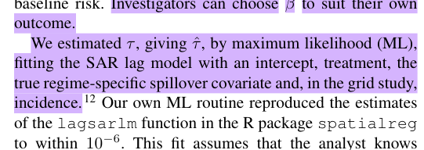

Text selected by annotation coordinates; line-wrap hyphens and mathematical glyph order may reflect PDF extraction. The image below preserves the marked original.

**Chapter 3 follow-up and related comments**

**Provisional chapter destination:** Methods → Spatial Structure, Outcome Model and Estimand; Estimation and Performance Criteria

Provisional topic mapping, not a verified line-level match or an approved revision.

**Related comments:** None assigned

Your notes / intended response

FCL-024PDF p. 2HighlightOpen

### Methods / Outcome model, estimation and allocation risk

#### Marked text

> This interval covered τ more reliably than the standard Wald interval, τˆ ± 1.96Sˆ︂E.

#### Surrounding text / location

This interval covered τ more reliably than the standard Wald interval, τ̂ ± 1.96 SÊ.

#### Annotation contents · flin33

> need reference

**View marked passage in the original PDF**

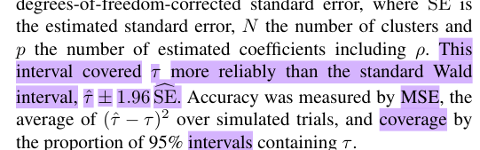

Text selected by annotation coordinates; line-wrap hyphens and mathematical glyph order may reflect PDF extraction. The image below preserves the marked original.

**Chapter 3 follow-up and related comments**

**Provisional chapter destination:** Methods → Spatial Structure, Outcome Model and Estimand; Estimation and Performance Criteria

Provisional topic mapping, not a verified line-level match or an approved revision.

**Related comments:** FCL-026 · FCL-027

Your notes / intended response

FCL-025PDF p. 2HighlightOpen

### Methods / Outcome model, estimation and allocation risk

#### Marked text

> MSE

#### Surrounding text / location

Accuracy was measured by MSE, the average of (τ̂ − τ)² over simulated trials, and coverage by the proportion of 95% intervals containing τ.

#### Annotation contents · flin33

> add "mean squared error"

**View marked passage in the original PDF**

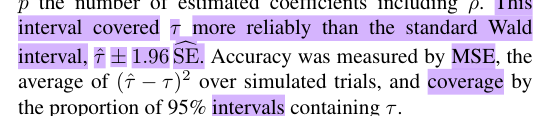

Text selected by annotation coordinates; line-wrap hyphens and mathematical glyph order may reflect PDF extraction. The image below preserves the marked original.

**Chapter 3 follow-up and related comments**

**Provisional chapter destination:** Methods → Spatial Structure, Outcome Model and Estimand; Estimation and Performance Criteria

Provisional topic mapping, not a verified line-level match or an approved revision.

**Related comments:** FCL-026 · FCL-027

Your notes / intended response

FCL-026PDF p. 2HighlightOpen

### Methods / Outcome model, estimation and allocation risk

#### Marked text

> intervals

#### Surrounding text / location

Accuracy was measured by MSE, the average of (τ̂ − τ)² over simulated trials, and coverage by the proportion of 95% intervals containing τ.

#### Annotation contents · flin33

> confidence intervals

**View marked passage in the original PDF**

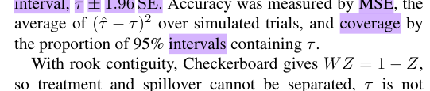

Text selected by annotation coordinates; line-wrap hyphens and mathematical glyph order may reflect PDF extraction. The image below preserves the marked original.

**Chapter 3 follow-up and related comments**

**Provisional chapter destination:** Methods → Spatial Structure, Outcome Model and Estimand; Estimation and Performance Criteria

Provisional topic mapping, not a verified line-level match or an approved revision.

**Related comments:** FCL-024 · FCL-025 · FCL-027

Your notes / intended response

FCL-027PDF p. 2HighlightOpen

### Methods / Outcome model, estimation and allocation risk

#### Marked text

> coverage

#### Surrounding text / location

Accuracy was measured by MSE, the average of (τ̂ − τ)² over simulated trials, and coverage by the proportion of 95% intervals containing τ.

#### Annotation contents · flin33

> "coverage was measured"

**View marked passage in the original PDF**

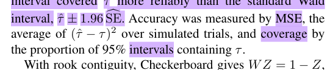

Text selected by annotation coordinates; line-wrap hyphens and mathematical glyph order may reflect PDF extraction. The image below preserves the marked original.

**Chapter 3 follow-up and related comments**

**Provisional chapter destination:** Methods → Spatial Structure, Outcome Model and Estimand; Estimation and Performance Criteria

Provisional topic mapping, not a verified line-level match or an approved revision.

**Related comments:** FCL-024 · FCL-025 · FCL-026

Your notes / intended response

FCL-028PDF p. 2HighlightOpen

### Methods / Outcome model, estimation and allocation risk

#### Marked text

> identified

#### Annotation contents · flin33

> identifiable?

**View marked passage in the original PDF**

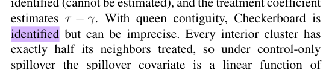

Text selected by annotation coordinates; line-wrap hyphens and mathematical glyph order may reflect PDF extraction. The image below preserves the marked original.

**Chapter 3 follow-up and related comments**

**Provisional chapter destination:** Methods → Spatial Structure, Outcome Model and Estimand; Estimation and Performance Criteria

Provisional topic mapping, not a verified line-level match or an approved revision.

**Related comments:** None assigned

Your notes / intended response

FCL-029PDF p. 2HighlightOpen

### Methods / Outcome model, estimation and allocation risk

#### Marked text

> A design with only one possible assignment has no spread, although its error can still be high.

#### Surrounding text / location

A design with only one possible assignment has no spread, although its error can still be high.

#### Annotation contents · flin33

> Is one assignment possible?

**View marked passage in the original PDF**

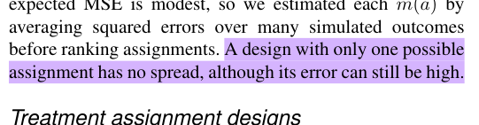

Text selected by annotation coordinates; line-wrap hyphens and mathematical glyph order may reflect PDF extraction. The image below preserves the marked original.

**Chapter 3 follow-up and related comments**

**Provisional chapter destination:** Methods → Spatial Structure, Outcome Model and Estimand; Estimation and Performance Criteria

Provisional topic mapping, not a verified line-level match or an approved revision.

**Related comments:** FCL-014 · FCL-043

Your notes / intended response

FCL-030PDF p. 2HighlightOpen

### Methods / Outcome model, estimation and allocation risk

#### Marked text

> S(Z)

#### Surrounding text / location

Equation (1) includes S(Z). The following paragraph defines S(Z) = γWZ for both arms and S(Z) = γ(1 − Z) ∘ WZ for control-only spillover.

#### Annotation contents · flin33

> Why not \gamma S(Z)?

**View marked passage in the original PDF**

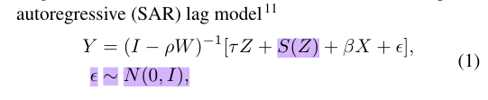

Text selected by annotation coordinates; line-wrap hyphens and mathematical glyph order may reflect PDF extraction. The image below preserves the marked original.

**Chapter 3 follow-up and related comments**

**Provisional chapter destination:** Methods → Spatial Structure, Outcome Model and Estimand; Estimation and Performance Criteria

Provisional topic mapping, not a verified line-level match or an approved revision.

**Related comments:** FCL-016 · FCL-056

Your notes / intended response

FCL-031PDF p. 2HighlightOpen

### Methods / Simulation study

#### Marked text

> regimes

#### Surrounding text / location

The simulation crossed ρ = 0, 0.01, 0.2, 0.5, γ = 0.5, 0.6, 0.7, 0.8, both spillover regimes and τ = 0.8, 1, 1.5, 2, 3.

#### Annotation contents · flin33

> regimes,

**View marked passage in the original PDF**

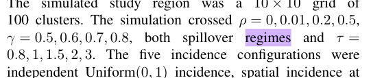

Text selected by annotation coordinates; line-wrap hyphens and mathematical glyph order may reflect PDF extraction. The image below preserves the marked original.

**Chapter 3 follow-up and related comments**

**Provisional chapter destination:** Methods → Heterogeneous Baseline Incidence; Simulation Design, Resampling, and Metrics

Provisional topic mapping, not a verified line-level match or an approved revision.

**Related comments:** None assigned

Your notes / intended response

FCL-032PDF p. 2HighlightOpen

### Methods / Simulation study

#### Marked text

> two dependence strengths (ρX = 0.2,0.5),

#### Surrounding text / location

The five incidence configurations were independent Uniform(0, 1) incidence, spatial incidence at two dependence strengths (ρX = 0.2, 0.5), and Poisson incidence at the same two strengths.

#### Annotation contents · flin33

> write the spatial model for X specifically?

**View marked passage in the original PDF**

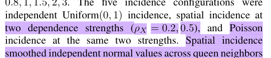

Text selected by annotation coordinates; line-wrap hyphens and mathematical glyph order may reflect PDF extraction. The image below preserves the marked original.

**Chapter 3 follow-up and related comments**

**Provisional chapter destination:** Methods → Heterogeneous Baseline Incidence; Simulation Design, Resampling, and Metrics

Provisional topic mapping, not a verified line-level match or an approved revision.

**Related comments:** FCL-033 · FCL-034 · FCL-035 · FCL-036 · FCL-042

Your notes / intended response

FCL-033PDF p. 2HighlightOpen

### Methods / Simulation study

#### Marked text

> Poisson

#### Surrounding text / location

The five incidence configurations were independent Uniform(0, 1) incidence, spatial incidence at two dependence strengths (ρX = 0.2, 0.5), and Poisson incidence at the same two strengths.

#### Annotation contents · flin33

> One normal and one Poisson?

**View marked passage in the original PDF**

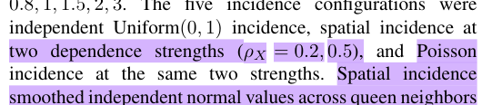

Text selected by annotation coordinates; line-wrap hyphens and mathematical glyph order may reflect PDF extraction. The image below preserves the marked original.

**Chapter 3 follow-up and related comments**

**Provisional chapter destination:** Methods → Heterogeneous Baseline Incidence; Simulation Design, Resampling, and Metrics

Provisional topic mapping, not a verified line-level match or an approved revision.

**Related comments:** FCL-032 · FCL-034

Your notes / intended response

FCL-034PDF p. 2HighlightOpen

### Methods / Simulation study

#### Marked text

> Spatial incidence smoothed independent normal values across queen neighbors with a SAR filter and mapped them to (0,1) with the normal distribution function

#### Surrounding text / location

Spatial incidence smoothed independent normal values across queen neighbors with a SAR filter and mapped them to (0,1) with the normal distribution function

#### Annotation contents · flin33

> How?

**View marked passage in the original PDF**

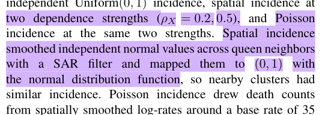

Text selected by annotation coordinates; line-wrap hyphens and mathematical glyph order may reflect PDF extraction. The image below preserves the marked original.

**Chapter 3 follow-up and related comments**

**Provisional chapter destination:** Methods → Heterogeneous Baseline Incidence; Simulation Design, Resampling, and Metrics

Provisional topic mapping, not a verified line-level match or an approved revision.

**Related comments:** FCL-032 · FCL-033

Your notes / intended response

FCL-035PDF p. 2HighlightOpen

### Methods / Simulation study

#### Marked text

> surface

#### Surrounding text / location

For each configuration we generated ten independent incidence surfaces, each shared by every parameter setting and design, and for surface k the assignments, outcomes and fitted model all used the same incidence Xk.

#### Annotation contents · flin33

> What does that mean by "surface k assignment"?

**View marked passage in the original PDF**

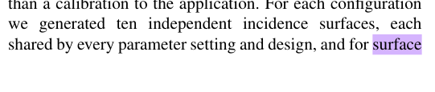

Only “surface” is highlighted at the bottom of page 2; the sentence continues on page 3. The reviewer’s wording refers to the longer passage.

**Chapter 3 follow-up and related comments**

**Provisional chapter destination:** Methods → Heterogeneous Baseline Incidence; Simulation Design, Resampling, and Metrics

Provisional topic mapping, not a verified line-level match or an approved revision.

**Related comments:** FCL-032 · FCL-042

Your notes / intended response